# Errors spec-seq

Florian Curvaia

27/05/2022

# AP1

## AP1 sample 1

```
   Genotype          Score_nomet          Score_met         Difference
 Length:64          Min.   :-0.643788   Min.   :-1.0326   Min.   :-1.9480
 Class :character   1st Qu.:-0.287183   1st Qu.:-0.7498   1st Qu.:-0.8201
 Mode  :character   Median :-0.001592   Median :-0.6020   Median :-0.5213
                    Mean   : 0.120623   Mean   :-0.5189   Mean   :-0.6395
                    3rd Qu.: 0.341243   3rd Qu.:-0.3797   3rd Qu.:-0.4230
                    Max.   : 1.954829   Max.   : 0.7248   Max.   : 0.1596
 Contains_CpG
 True:64
```

Plot of all sequences

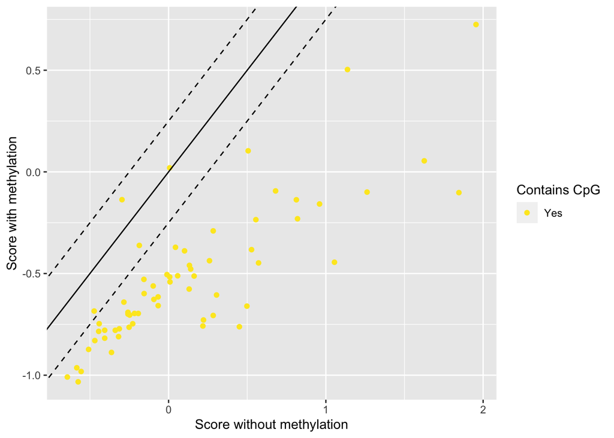

```r
ggplot(AP1_1, aes(x=Score_nomet, y=Score_met, color=Contains_CpG))+geom_point()+geom_abline(slope=1, intercept = 0) + geom_abline(slope=1, intercept = 0.25, linetype="dashed") + geom_abline(slope=1, intercept = -0.25, linetype="dashed")+scale_color_viridis(discrete=TRUE, direction=-1, name="Contains CpG", labels=("Yes"))+xlab("Score without methylation")+ylab("Score with methylation")
```

```r
ggsave(paste(path, "AP1_1/Plots/AP1_1_scatter.png", sep="/"))
```

Violin plot of distribution of the scores between methylated and non methylated sequences.

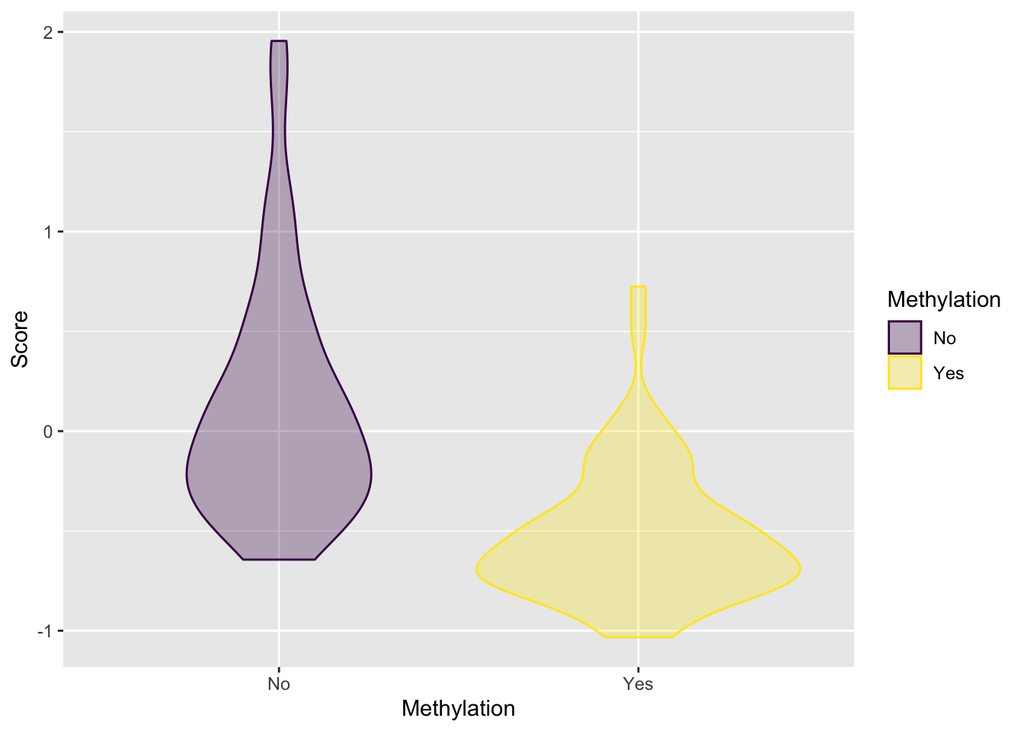

```r
AP1_1_mod <- melt(AP1_1, measure.vars = c('Score_nomet', 'Score_met'), variable.name="Methylation")
levels(AP1_1_mod$Methylation) <- c("No", "Yes")
ggplot(data=AP1_1_mod)+geom_violin(aes(Methylation, value, color=Methylation, fill=Methylation))+scale_color_viridis(discrete=TRUE)+scale_fill_viridis(discrete = TRUE, alpha=0.3)+ylab("Score")
```

```r
ggsave(paste(path, "AP1_1/Plots/AP1_1_violin.png", sep="/"))
```

Are the non-methylated scores normally distributed ?

```r
shapiro.test(AP1_1$Score_nomet)
```

```
    Shapiro-Wilk normality test

data:  AP1_1$Score_nomet
W = 0.88785, p-value = 2.873e-05
```

P-value<<0.05, so we reject the null hyptohesis of normal distribution

Are the methylated scores normally distributed ?

```r
shapiro.test(AP1_1$Score_met)
```

```
    Shapiro-Wilk normality test

data:  AP1_1$Score_met
W = 0.90351, p-value = 0.0001088
```

P-value<<0.05, so we reject the null hyptohesis of normal distribution

Is there a change between non-methylated and methylated sequences

```r
wilcox.test(AP1_1$Score_nomet, AP1_1$Score_met, paired=TRUE)
```

```
    Wilcoxon signed rank test with continuity correction

data:  AP1_1$Score_nomet and AP1_1$Score_met
V = 2077, p-value = 4.161e-12
alternative hypothesis: true location shift is not equal to 0
```

Rejection of null hypothesis of no difference between not methylated and methylated sequences

Are the scores of methylated sequences greater than the one of non-methylated sequences ?

```r
wilcox.test(AP1_1$Score_nomet, AP1_1$Score_met, paired=TRUE, alternative="less")
```

```
    Wilcoxon signed rank test with continuity correction

data:  AP1_1$Score_nomet and AP1_1$Score_met
V = 2077, p-value = 1
alternative hypothesis: true location shift is less than 0
```

Are the scores of methylated sequences smaller than the one of non-methylated sequences ?

```r
wilcox.test(AP1_1$Score_nomet, AP1_1$Score_met, paired=TRUE, alternative="greater")
```

```
    Wilcoxon signed rank test with continuity correction

data:  AP1_1$Score_nomet and AP1_1$Score_met
V = 2077, p-value = 2.081e-12
alternative hypothesis: true location shift is greater than 0
```

## AP1 sample 2

```
   Genotype          Score_nomet         Score_met         Difference
 Length:64          Min.   :-0.41800   Min.   :-0.7911   Min.   :-1.9991
 Class :character   1st Qu.:-0.04002   1st Qu.:-0.5254   1st Qu.:-0.8491
 Mode  :character   Median : 0.23216   Median :-0.3730   Median :-0.5470
                    Mean   : 0.37092   Mean   :-0.2868   Mean   :-0.6577
                    3rd Qu.: 0.59351   3rd Qu.:-0.1285   3rd Qu.:-0.4335
                    Max.   : 2.30761   Max.   : 0.9758   Max.   : 0.1441
 Contains_CpG
 True:64
```

Plot of all sequences

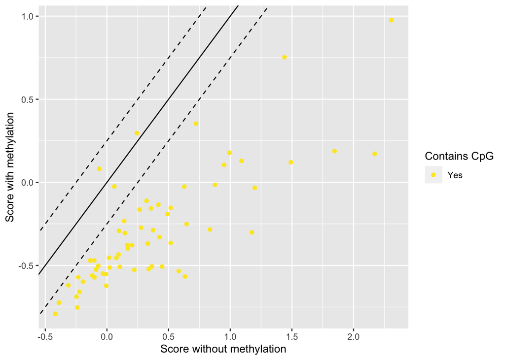

```r
ggplot(AP1_2, aes(x=Score_nomet, y=Score_met, color=Contains_CpG))+geom_point()+geom_abline(slope=1, intercept = 0) + geom_abline(slope=1, intercept = 0.25, linetype="dashed") + geom_abline(slope=1, intercept = -0.25, linetype="dashed")+scale_color_viridis(discrete=TRUE, direction=-1, name="Contains CpG", labels=("Yes"))+xlab("Score without methylation")+ylab("Score with methylation")
```

```r
ggsave(paste(path, "AP1_2/Plots/AP1_2_scatter.png", sep="/"))
```

Violin plot of distribution of the scores between methylated and non methylated sequences.

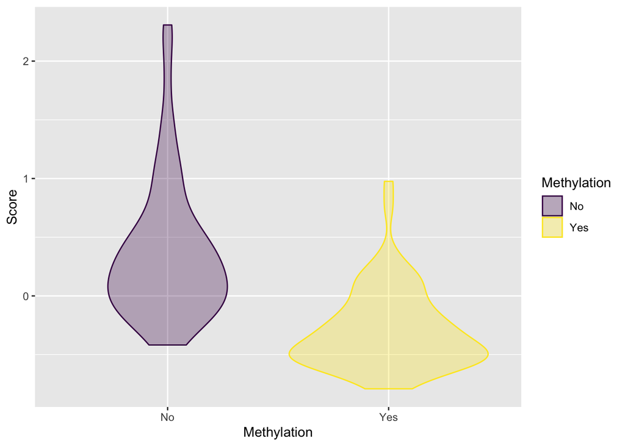

```r
AP1_2_mod <- melt(AP1_2, measure.vars = c('Score_nomet', 'Score_met'), variable.name="Methylation")
levels(AP1_2_mod$Methylation) <- c("No", "Yes")
ggplot(data=AP1_2_mod)+geom_violin(aes(Methylation, value, color=Methylation, fill=Methylation))+scale_color_viridis(discrete=TRUE)+scale_fill_viridis(discrete = TRUE, alpha=0.3)+ylab("Score")
```

```r
ggsave(paste(path, "AP1_2/Plots/AP1_2_violin.png", sep="/"))
```

Are the non-methylated scores normally distributed ?

```r
shapiro.test(AP1_2$Score_nomet)
```

```
    Shapiro-Wilk normality test

data:  AP1_2$Score_nomet
W = 0.87994, p-value = 1.519e-05
```

P-value<<0.05, so we reject the null hyptohesis of normal distribution

Are the methylated scores normally distributed ?

```r
shapiro.test(AP1_2$Score_met)
```

```
    Shapiro-Wilk normality test

data:  AP1_2$Score_met
W = 0.8967, p-value = 6.022e-05
```

P-value<<0.05, so we reject the null hyptohesis of normal distribution

Is there a change between non-methylated and methylated sequences

```r
wilcox.test(AP1_2$Score_nomet, AP1_2$Score_met, paired=TRUE)
```

```
    Wilcoxon signed rank test with continuity correction

data:  AP1_2$Score_nomet and AP1_2$Score_met
V = 2076, p-value = 4.362e-12
alternative hypothesis: true location shift is not equal to 0
```

Rejection of null hypothesis of no difference between not methylated and methylated sequences

Are the scores of methylated sequences greater than the one of non-methylated sequences ?

```r
wilcox.test(AP1_2$Score_nomet, AP1_2$Score_met, paired=TRUE, alternative="less")
```

```
    Wilcoxon signed rank test with continuity correction

data:  AP1_2$Score_nomet and AP1_2$Score_met
V = 2076, p-value = 1
alternative hypothesis: true location shift is less than 0
```

Are the scores of methylated sequences smaller than the one of non-methylated sequences ?

```r
wilcox.test(AP1_2$Score_nomet, AP1_2$Score_met, paired=TRUE, alternative="greater")
```

```
    Wilcoxon signed rank test with continuity correction

data:  AP1_2$Score_nomet and AP1_2$Score_met
V = 2076, p-value = 2.181e-12
alternative hypothesis: true location shift is greater than 0
```

# CTCF

## CTCF sample 1

```r
CTCF_1 <- read.table(paste(path, "CTCF_1/CTCF_1_comparison.csv", sep="/"), header=T, sep="\t")
CTCF_1$Contains_CpG <- as.factor(CTCF_1$Contains_CpG)
summary(CTCF_1)
```

```
   Genotype          Score_nomet        Score_met         Difference
 Length:1266        Min.   :-4.5131   Min.   :-4.5783   Min.   :-1.128716
 Class :character   1st Qu.:-2.8139   1st Qu.:-2.9210   1st Qu.:-0.144848
 Mode  :character   Median :-2.0628   Median :-2.0221   Median :-0.003024
                    Mean   :-1.3940   Mean   :-1.4221   Mean   :-0.028064
                    3rd Qu.: 0.1878   3rd Qu.: 0.2803   3rd Qu.: 0.106542
                    Max.   : 2.6192   Max.   : 2.7268   Max.   : 1.190985
 Contains_CpG
 False:865
 True :401
```

Plot with both sequences having CpG and sequences not having CpG

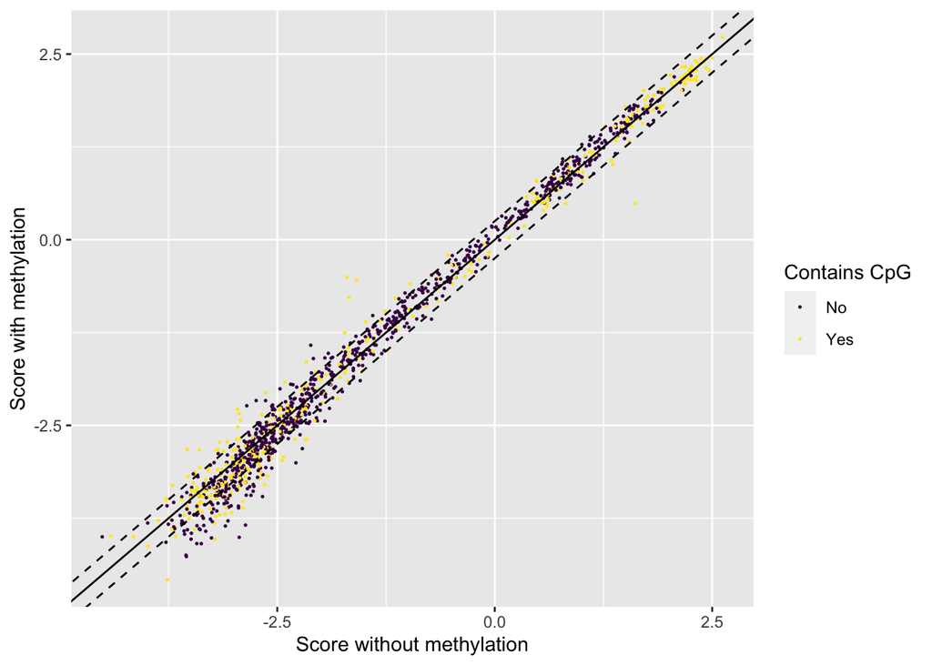

```r
ggplot(CTCF_1, aes(x=Score_nomet, y=Score_met, color=Contains_CpG))+geom_point(size=0.25)+geom_abline(slope=1, intercept = 0) + geom_abline(slope=1, intercept = 0.25, linetype="dashed") + geom_abline(slope=1, intercept = -0.25, linetype="dashed")+scale_color_viridis(discrete=TRUE, name="Contains CpG", labels=c("No","Yes"))+xlab("Score without methylation")+ylab("Score with methylation")
```

```r
ggsave(paste(path, "CTCF_1/Plots/CTCF_1_scatter.png", sep="/"))
```

Plot with sequences having CpG

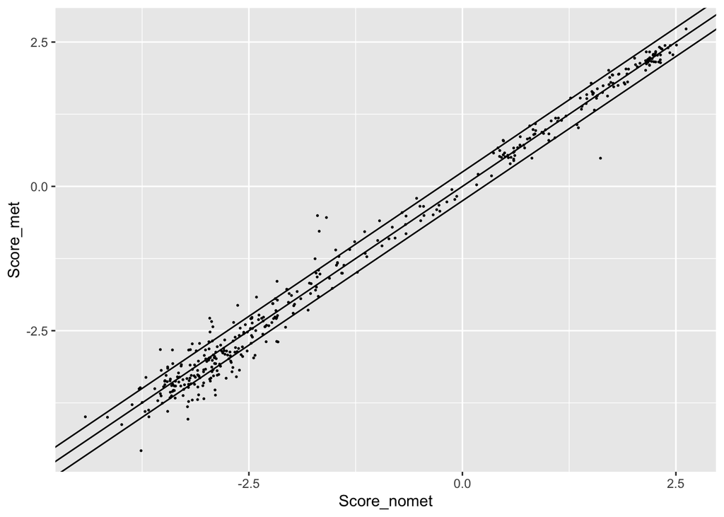

```r
CTCF_1_CG <- CTCF_1[CTCF_1$Contains_CpG == "True",]
CTCF_1_no_CG <- CTCF_1[CTCF_1$Contains_CpG == "False",]
ggplot(CTCF_1_CG, aes(x=Score_nomet, y=Score_met))+geom_point(size=0.25)+geom_abline(slope=1, intercept = 0) + geom_abline(slope=1, intercept = 0.25) + geom_abline(slope=1, intercept = -0.25)
```

Plot with sequences not having CpG

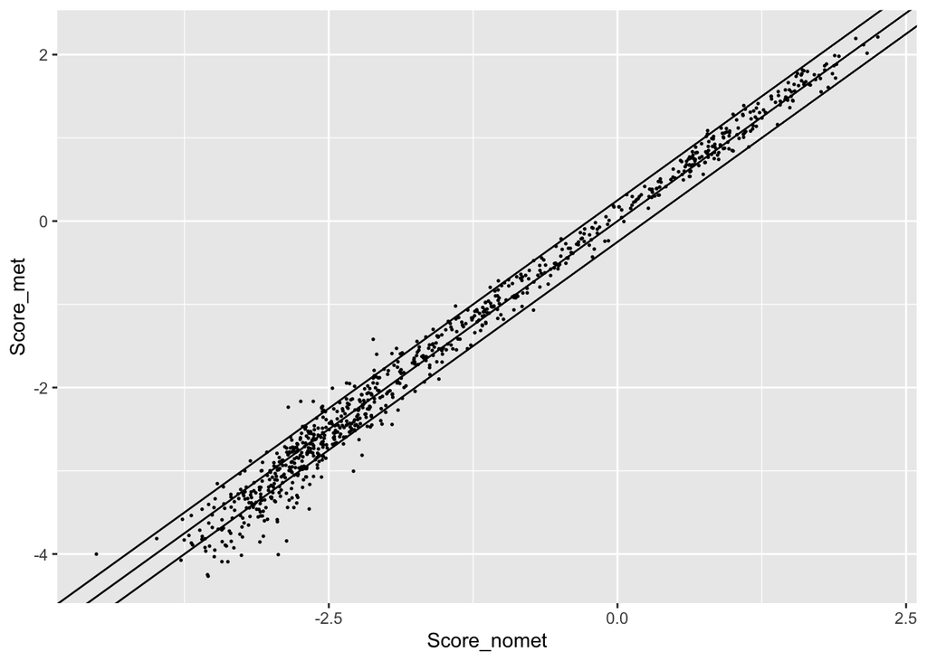

```r
ggplot(CTCF_1_no_CG, aes(x=Score_nomet, y=Score_met))+geom_point(size=0.25)+geom_abline(slope=1, intercept = 0) + geom_abline(slope=1, intercept = 0.25) + geom_abline(slope=1, intercept = -0.25)
```

Violin plot of distribution of the scores between methylated and non methylated sequences.

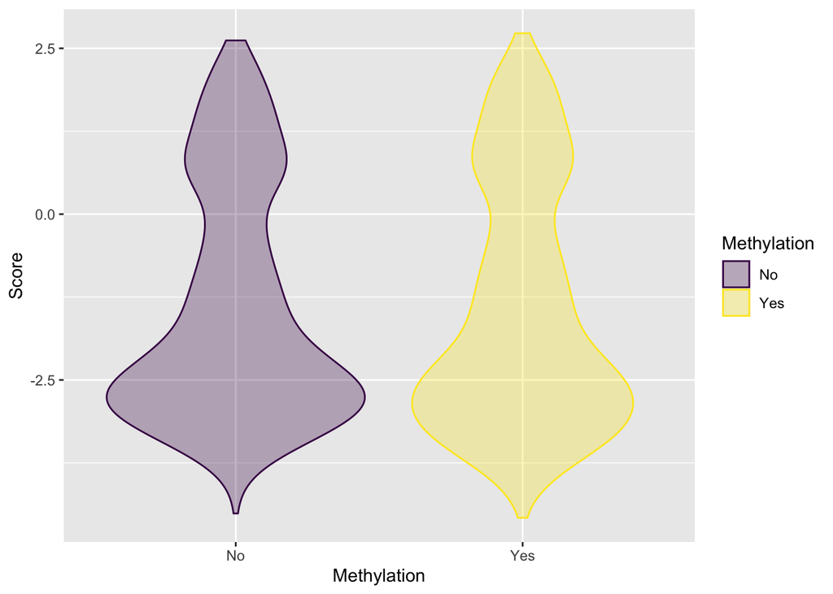

```r
CTCF_1_mod <- melt(CTCF_1, measure.vars = c('Score_nomet', 'Score_met'), variable.name="Methylation")
levels(CTCF_1_mod$Methylation) <- c("No", "Yes")
ggplot(data=CTCF_1_mod)+geom_violin(aes(Methylation, value, color=Methylation, fill=Methylation))+scale_color_viridis(discrete=TRUE)+scale_fill_viridis(discrete = TRUE, alpha=0.3)+ylab("Score")
```

```r
ggsave(paste(path, "CTCF_1/Plots/CTCF_1_violin.png", sep="/"))
```

Are the non-methylated scores normally distributed ?

```r
shapiro.test(CTCF_1$Score_nomet)
```

```
    Shapiro-Wilk normality test

data:  CTCF_1$Score_nomet
W = 0.90226, p-value < 2.2e-16
```

P-value<<0.05, so we reject the null hypothesis of normal distribution

Are the methylated scores normally distributed ?

```r
shapiro.test(CTCF_1$Score_met)
```

```
    Shapiro-Wilk normality test

data:  CTCF_1$Score_met
W = 0.91693, p-value < 2.2e-16
```

P-value<<0.05, so we reject the null hyptohesis of normal distribution

Is there a change between non-methylated and methylated sequences

```r
wilcox.test(CTCF_1$Score_nomet, CTCF_1$Score_met, paired=TRUE)
```

```
    Wilcoxon signed rank test with continuity correction

data:  CTCF_1$Score_nomet and CTCF_1$Score_met
V = 438694, p-value = 0.003773
alternative hypothesis: true location shift is not equal to 0
```

Rejection of null hypothesis of no difference between not methylated and methylated sequences.

Are the scores of methylated sequences greater than the one of non-methylated sequences ?

```r
wilcox.test(CTCF_1$Score_nomet, CTCF_1$Score_met, paired=TRUE, alternative="less")
```

```
    Wilcoxon signed rank test with continuity correction

data:  CTCF_1$Score_nomet and CTCF_1$Score_met
V = 438694, p-value = 0.9981
alternative hypothesis: true location shift is less than 0
```

Are the scores of methylated sequences smaller than the one of non-methylated sequences ?

```r
wilcox.test(CTCF_1$Score_nomet, CTCF_1$Score_met, paired=TRUE, alternative="greater")
```

```
    Wilcoxon signed rank test with continuity correction

data:  CTCF_1$Score_nomet and CTCF_1$Score_met
V = 438694, p-value = 0.001886
alternative hypothesis: true location shift is greater than 0
```

The results are not really consistent with landscapes’ results. Let’s try to filter the data by only looking at the sequences which contain at least on CpG dinucleotide.

First, is the scores of methylated sequences greater than the one of non-methylated sequences ?

```
    Wilcoxon signed rank test with continuity correction

data:  CTCF_1_CG$Score_nomet and CTCF_1_CG$Score_met
V = 45325, p-value = 0.9848
alternative hypothesis: true location shift is less than 0
```

Then, is the scores of methylated sequences smaller than the one of non-methylated sequences ?

```
    Wilcoxon signed rank test with continuity correction

data:  CTCF_1_CG$Score_nomet and CTCF_1_CG$Score_met
V = 45325, p-value = 0.01526
alternative hypothesis: true location shift is greater than 0
```

Analyse spread of the scores of sequences which doesn’t contain any CpG:

```r
quantile(CTCF_1_no_CG$Difference, probs = seq(.1, .9, by = .1))
```

```
         10%          20%          30%          40%          50%          60%
-0.293727947 -0.180942929 -0.099127379 -0.046343570  0.003815588  0.045203791
         70%          80%          90%
 0.081561336  0.135774913  0.188749175
```

```r
quantile(CTCF_1_no_CG$Difference, probs = seq(.05, .95, by = .05))
```

```
          5%          10%          15%          20%          25%          30%
-0.407648456 -0.293727947 -0.226725930 -0.180942929 -0.135801542 -0.099127379
         35%          40%          45%          50%          55%          60%
-0.072301307 -0.046343570 -0.016857117  0.003815588  0.026960460  0.045203791
         65%          70%          75%          80%          85%          90%
 0.066273353  0.081561336  0.106555973  0.135774913  0.159370512  0.188749175
         95%
 0.238349641
```

Let’s try with absolute difference:

```r
quantile(abs(CTCF_1_no_CG$Difference), probs = seq(.1, .9, by = .1))
```

```
       10%        20%        30%        40%        50%        60%        70%
0.02208931 0.04525952 0.06804962 0.09011207 0.12135915 0.15275263 0.18448252
       80%        90%
0.23326918 0.32634909
```

```r
quantile(abs(CTCF_1_no_CG$Difference), probs = seq(.05, .95, by = .05))
```

```
        5%        10%        15%        20%        25%        30%        35%
0.01057406 0.02208931 0.03538667 0.04525952 0.05869386 0.06804962 0.07824679
       40%        45%        50%        55%        60%        65%        70%
0.09011207 0.10426536 0.12135915 0.13582342 0.15275263 0.16760879 0.18448252
       75%        80%        85%        90%        95%
0.21191090 0.23326918 0.27067012 0.32634909 0.45606735
```

Let’s compute the proportion of sequences containing no CpG with a difference inside the 0.25 deviation bound used for now:

```r
dev_CTCF_1 <- CTCF_1_no_CG[abs(CTCF_1_no_CG$Difference)<=0.25,]
nrow(dev_CTCF_1)/nrow(CTCF_1_no_CG)
```

```
[1] 0.8277457
```

Then let’s see if there is a difference in the effect of methylation between sequences with at least one CpG and sequences without any:

```r
shapiro.test(CTCF_1_no_CG$Difference)
```

```
    Shapiro-Wilk normality test

data:  CTCF_1_no_CG$Difference
W = 0.95351, p-value = 6.683e-16
```

```r
wilcox.test(CTCF_1_no_CG$Difference, CTCF_1_CG$Difference)
```

```
    Wilcoxon rank sum test with continuity correction

data:  CTCF_1_no_CG$Difference and CTCF_1_CG$Difference
W = 178198, p-value = 0.4311
alternative hypothesis: true location shift is not equal to 0
```

## CTCF sample 2

```r
CTCF_2 <- read.table(paste(path, "CTCF_2/CTCF_2_comparison.csv", sep="/"), header=T, sep="\t")
CTCF_2$Contains_CpG <- as.factor(CTCF_2$Contains_CpG)
summary(CTCF_2)
```

```
   Genotype          Score_nomet         Score_met          Difference
 Length:1264        Min.   :-1.19999   Min.   :-2.20759   Min.   :-1.03093
 Class :character   1st Qu.:-0.47277   1st Qu.:-0.69085   1st Qu.:-0.26932
 Mode  :character   Median :-0.24555   Median :-0.38004   Median :-0.14436
                    Mean   :-0.20494   Mean   :-0.36653   Mean   :-0.16159
                    3rd Qu.: 0.05543   3rd Qu.:-0.02344   3rd Qu.:-0.03019
                    Max.   : 0.96364   Max.   : 1.19379   Max.   : 0.50897
 Contains_CpG
 False:864
 True :400
```

Plot with both sequences having CpG and sequences not having CpG

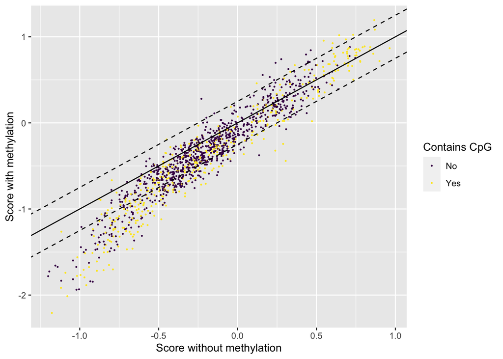

```r
ggplot(CTCF_2, aes(x=Score_nomet, y=Score_met, color=Contains_CpG))+geom_point(size=0.25)+geom_abline(slope=1, intercept = 0) + geom_abline(slope=1, intercept = 0.25, linetype="dashed") + geom_abline(slope=1, intercept = -0.25, linetype="dashed")+scale_color_viridis(discrete=TRUE, name="Contains CpG", labels=c("No","Yes"))+xlab("Score without methylation")+ylab("Score with methylation")
```

```r
ggsave(paste(path, "CTCF_2/Plots/CTCF_2_scatter.png", sep="/"))
```

Plot with sequences having CpG

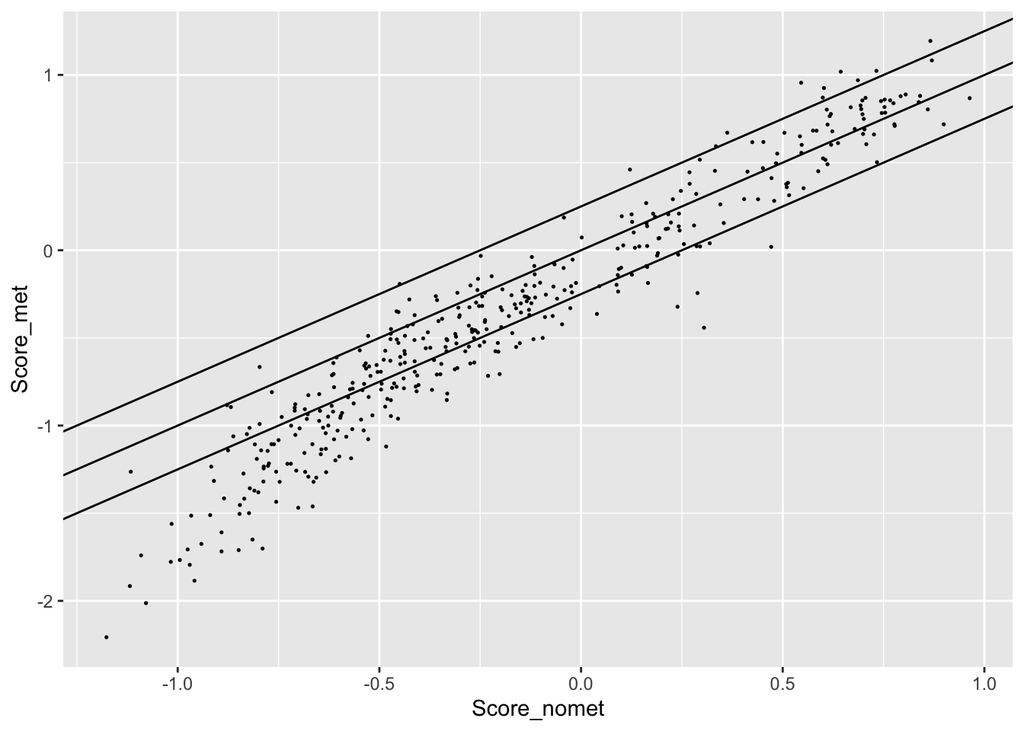

```r
CTCF_2_CG <- CTCF_2[CTCF_2$Contains_CpG == "True",]
CTCF_2_no_CG <- CTCF_2[CTCF_2$Contains_CpG == "False",]
ggplot(CTCF_2_CG, aes(x=Score_nomet, y=Score_met))+geom_point(size=0.25)+geom_abline(slope=1, intercept = 0) + geom_abline(slope=1, intercept = 0.25) + geom_abline(slope=1, intercept = -0.25)
```

Plot with sequences not having CpG

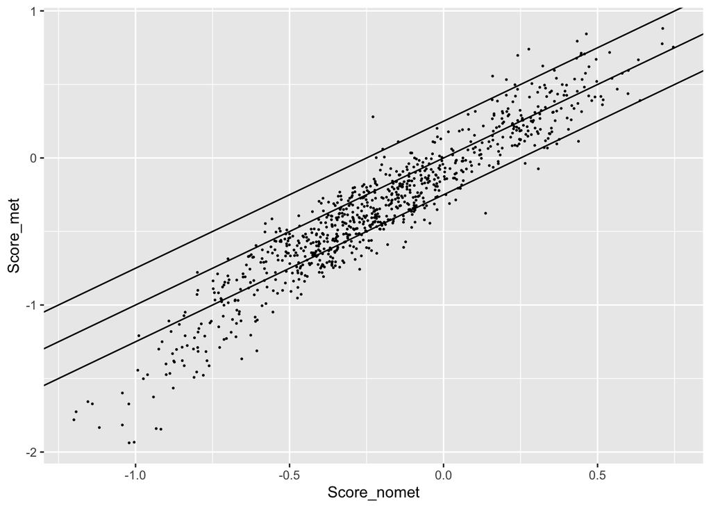

```r
ggplot(CTCF_2_no_CG, aes(x=Score_nomet, y=Score_met))+geom_point(size=0.25)+geom_abline(slope=1, intercept = 0) + geom_abline(slope=1, intercept = 0.25) + geom_abline(slope=1, intercept = -0.25)
```

Violin plot of distribution of the scores between methylated and non methylated sequences.

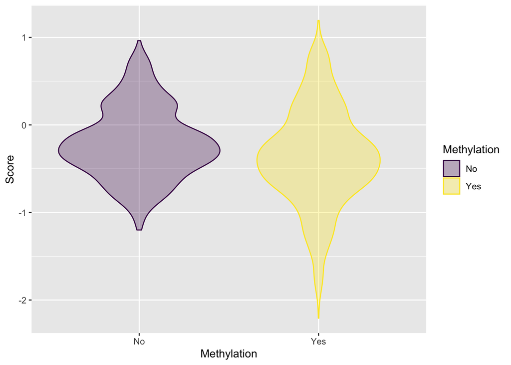

```r
CTCF_2_mod <- melt(CTCF_2, measure.vars = c('Score_nomet', 'Score_met'), variable.name="Methylation")
levels(CTCF_2_mod$Methylation) <- c("No", "Yes")
ggplot(data=CTCF_2_mod)+geom_violin(aes(Methylation, value, color=Methylation, fill=Methylation))+scale_color_viridis(discrete=TRUE)+scale_fill_viridis(discrete = TRUE, alpha=0.3)+ylab("Score")
```

```r
ggsave(paste(path, "CTCF_2/Plots/CTCF_2_violin.png", sep="/"))
```

Are the non-methylated scores normally distributed ?

```r
shapiro.test(CTCF_2$Score_nomet)
```

```
    Shapiro-Wilk normality test

data:  CTCF_2$Score_nomet
W = 0.98833, p-value = 1.658e-08
```

P-value<<0.05, so we reject the null hyptohesis of normal distribution